# Week3_Notes

February 4, 2016

## T distribution

We talked about the T test, but a student brought up T test vs T distribution last week. What is it?

## T distribution

- This distribution was discovered by W. S. Gosset, the chief statistician of the Guinness brewery in Dublin, Ireland. He discovered the t-distribution in order to deal with small samples arising in statistical quality control.
- The brewery had a policy against employees publishing under their own names, thus he published is results about the t-distribution under the pen name "Student", and that name has become attached to the distribution.

## T distribution vs Normal Distribution

- The normal distribution is used when the population distribution of data is assumed normal.
- The t distribution (aka, Student's t-distribution) is a probability distribution that is used to estimate population parameters when the sample size is small and/or when the population variance is unknown

## T distribution

If \(\bar{X}\) is the sample mean and S the sample standard deviation for a random sample of size \(n\) from a population with mean \(\mu\) and standard deviation \(\sigma\), define

\[ Z = \frac{\bar{X} - \mu}{\sigma/\sqrt{n}} \] and \[ T =\frac{\bar{X} - \mu}{se(\bar{X})} = \frac{\bar{X} - \mu}{S / \sqrt{n}} \]

## T distribution

We know:

- both Z and T are approximately Normal(0, 1), if n is large.
- Z is exactly Normal(0, 1) regardless of the size of n, if the population distribution is exactly normal.
- T is exactly Student(n - 1), if the population distribution is exactly normal.

## T distribution

- We know item 3 just by definition. That is how the t-distribution was originally defined.
- Comparing 1 and 3, it is clear that the t-distribution is close to the Normal(0, 1) distribution if n is large. Hence the difference only matters when n is small.
- For this reason the t-distribution is sometimes called a "small sample" distribution, but that name is misleading in two ways

## T distribution

Often times we don't know the standard deviation or variance of a distribution.

The distribution of T of sample size \(n\) has degrees of freedom \(n-1\) for all sample sizes n large or small. The key assumption is not that n is small, but that the population is exactly normal.

## T distribution compare curves (part 2)

```r
compareCurves<-function(){
x <- seq(-4, 4, length=100)
hx <- dnorm(x)
degf <- c(1, 3, 8, 30)
colors <- c("red", "blue", "darkgreen", "gold", "black")
labels <- c("df=1", "df=3", "df=8", "df=30", "normal")
plot(x, hx, type="l", lty=2, xlab="x value",ylab="Density",
     main="Comparison of t Distributions")
for (i in 1:4){lines(x, dt(x,degf[i]), lwd=2, col=colors[i])}
legend("topright", inset=.05, title="Distributions",labels, lwd=2, lty=c(1, 1, 1, 1, 2), col=colors)
}
```

## T distribution compare curves (part 3)

increasing in sample size means we approach normal distribution (tallest one)

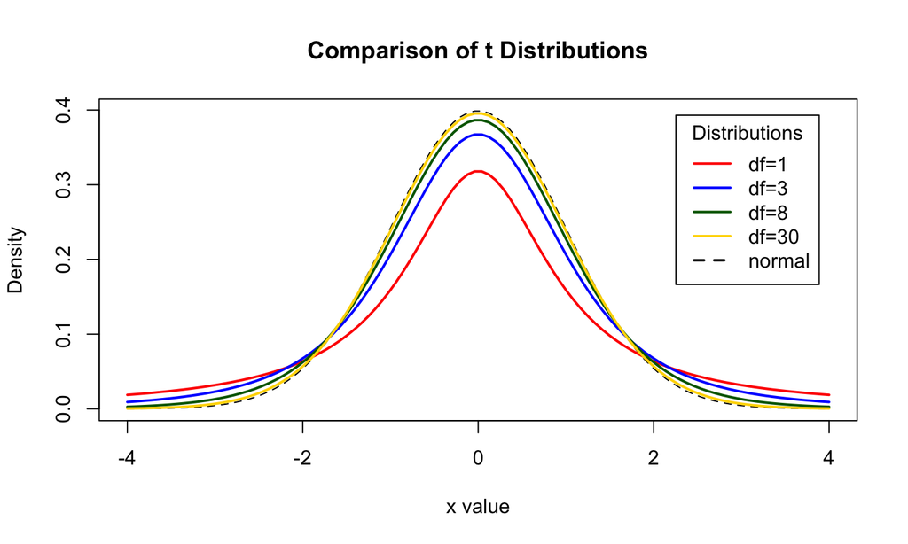

```r
compareCurves()
```

## More on the T distribution.

\(S\) the standard deviation that we have estimated introduces variability from samples to samples.

The degrees of freedom (df) are a measure of the amount of information available in the data that can be used to estimate the variance.

The degrees of freedom are n - 1 rather than n because we lose 1 df by estimating the sample mean \(\bar{x}\)

## Homework

- If you have any questions please email me and we can meet and work on it.
- If you need an extension on homework, please let me know as we did have a snow day last week.

## Difficult Material

- One of the difficulties of this is that it combines biology, stats, and programming.
- Don't feel bad if this is difficult, because it is.

## Bioconductor

Bioconductor is, for R, the largest library to do bioinformatics and statistical genetics.

## Install Bioconductor

To install

```r
## try http:// if https:// URLs are not supported
source("https://bioconductor.org/biocLite.R")
```

```
## Bioconductor version 3.2 (BiocInstaller 1.20.1), ?biocLite for help
```

```r
biocLite()
```

[output not shown]

[output not shown]

[output not shown]

## Locus

Think of this an interval or a union of intervals across a set of base pairs.

## Linkage Disequilibrium

Linkage equilibrium occurs when the genotype present at one locus is independent of the genotype at a second locus. Linkage disequilibrium occurs when genotypes at the two loci are not independent of another.

## Calculation of Linkage Disequilibrium

Suppose there are two genes on Chromosome 5 of James, each with two alleles

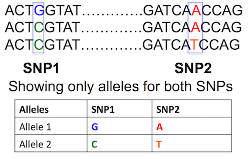

## Linkage Disequilibrium

For shortage, Linkage Disequilibrium is abreviated LD

i.e. Assume we are in LD.

## Distances Among East Coast Cities

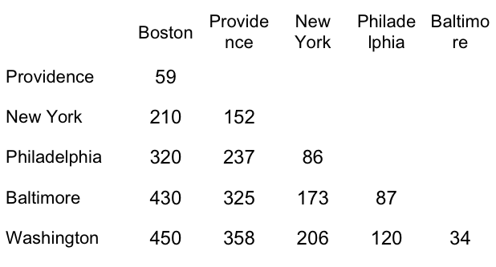

## Distances Among East Coast Cities (part 2)

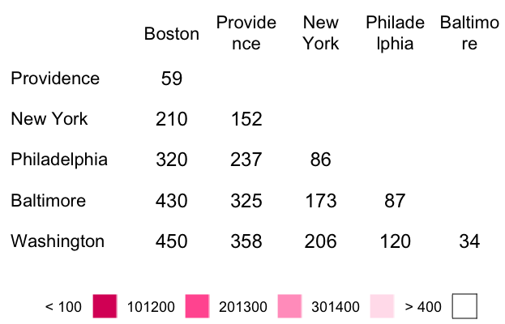

## Distances Among East Coast Cities (part 3)

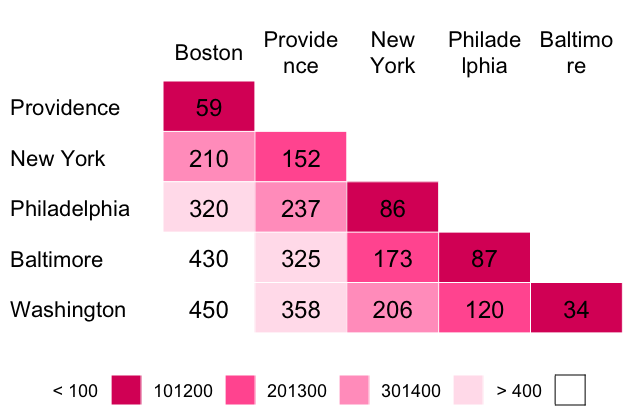

## Distances Among East Coast Cities (part 4)

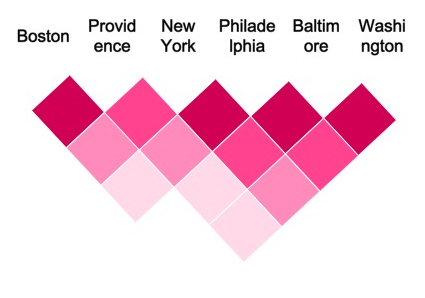

This is called an LD Block

## Linkage Disequilibrium

For better understanding of LD calculation, it is divided into five steps:

## LD Calculation Step 1

If p1 and p2 =frequency of the alleles at SNP1 and q1 and q2 =frequency of the alleles at SNP2 then in tabular form it could be written as follows

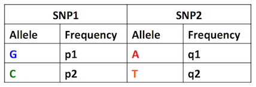

## Haplotype Defintion

A haplotype is, in the simplest terms, a specific group of genes or alleles that progeny inherited from one parent.

This means what variants in each gene does mom or dad pass down to child.

The haplotype frequency, then, is the frequency that a particular haplotype exists at a particular locus for particular alleles.

You can read more about haplotype frequency estimation here: http://www.stat.washington.edu/thompson/Stat550/Notes/2013/Chap_1_Secs_5-6.pdf

## LD Calculation Step 2

From our example of two SNPs each with two alleles all possible haplotypes are

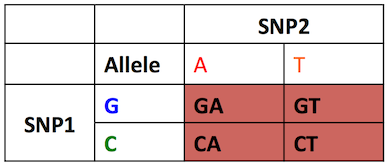

## LD Calculation Step 2 (part 2)

Suppose haplotype frequencies are as follows:

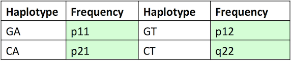

## Linkage Equilibrium (Step 3)

When haplotype frequencies are equal to the product of their corresponding allele frequencies, it means the loci are in linkage equilibrium.

| Haplotype Frequency |  | Product of Allele Frequency |
| --- | --- | --- |
| \(p_{11}\) | = | \(p_1q_1\) |
| \(p_{12}\) | = | \(p_1q_2\) |
| \(p_{21}\) | = | \(p_2q_1\) |
| \(p_{22}\) | = | \(p_2q_2\) |

## Step 4: Calculate Difference

We can deduce linkage disequilibrium for each haplotype as the deviation of observed haplotype frequency from its corresponding allelic frequencies expected under equilibrium.

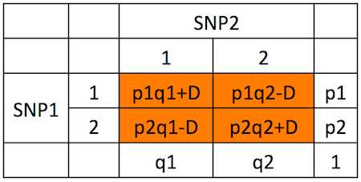

## Step 4: Calculate Difference

After solving above for D, we get as follows:

\[ D_{11} = p_{11} - p_1q_1 \\ D_{12} = p_{12} - p_1q_2 \\ D_{21} = p_{21} - p_2q_1 \\ D_{22} = p_{22} - p_2q_2 \]

Where the \(D_{ij}\)'s are our difference, the \(p_{ij}\)'s are the observed, and the \(p_iq_j\)'s are our expectation under equilibrium.

## Step 5: Calculation of Linkage Disequilibrium Measure D

While we are not going to prove, this (maybe an exercise?), the measure we can show to be:

\[ D = p_{11}p_{22} − p_{12}p_{21} \]

## LD Example 1

If allele frequencies of \(p_1\) and \(q_1\) are both 0.5 and equilibrium occurs (only Ab and aB exist in the population)

\[ P_{11} = p_1q_1= (0.5)(0.5) = 0.25 \\ P_{22} = p_2q_2= (0.5)(0.5) = 0.25 \\ P_{12} = p_1q_2= (0.5)(0.5) = 0.25 \\ P_{21} = p_2q_1= (0.5)(0.5) = 0.25 \]

## LD Example 1

Now calculate D \[ \begin{align} D & = (P_{11})(P_{22}) -(P_{12})(P_{21}) \\ & = (0.25)(0.25) - (0.25)(0.25) = 0 \end{align} \] So what has happened here?

## Standardization of LD Measure (D)

- Sometimes, depending on allele frequency of two loci, the value of D can be negative
- Why is this a problem?
- To solve this, we standardize the value.

## Standardization of D

In a common standardization method, a relative measure of disequilibrium (D) compared to its maximum is used: \[ D` = \frac{D}{D_{max}} \]

When D is positive: \(D_{max} = min[(p_1q_2)\,or\,(p_2q_1)]\)

When D is negative: \(D_{max} = min[(p_1q_1)\,or\,(p_2q_2)]\)

This standardization makes D-values range between 0 and 1

## Correlation Coefficient as a Measure of LD

Another commonly used measure to calculate LD between loci is Pearson coefficient of correlation (r) \[ r = \frac{D}{\sqrt{p_1p_2q_1q_2}} = \frac{D}{\sqrt{p_1(1-p_1)q_1(1-q_1)}} \] However, squared coefficient of correlation (\(r^2\)) is often used to remove the arbitrary sign introduced.

Why are these two quantities the same?

## Degrees of Freedom

- The number of degrees of freedom is the number of values in the final calculation of a statistic that are free to vary.
- The number of independent ways by which a dynamic system can move, without violating any constraint imposed on it, is called number of degrees of freedom.

## Chi Squared Distribution

If \(Z_1, . . . , Z_k\) are independent standard normal random variables, then \[ \chi^2 = Z_1^2 + . . . + Z_k^2 \] has a \(\chi^2\) distribution with k degrees of freedom.

## Chi Squared Distribution Part 2

The functions **pchisq()** and qchisq() find probabilities and quantiles, respectively, from the χ 2 distributions

## Testing for LD with D

- \(D_{ij} = 0\) corresponds to the status of no linkage disequilibrium
- It is often of interest to test the null hypothesis

\[ H_0 : D_{ij} = 0 \\ H_a : D_{ij} \neq 0 \]

Look familiar? As this turns out, we can't use our standard normal approach.

## Testing for LD with D (part 2)

One way to do this is to use a chi-square statistic z:

\[ Z^2 = \left(\frac{\hat{D_{ij}}-E_0(\hat{D_{ij}})}{Var_0(\hat{D_{ij}})}\right)^2 \]

Where \(E_0\) is the expected value and \(Var_0\) is the variance calculated under the assumption of no LD i.e. \(D_{ij} = 0\)

## Measuring LD with \(r^2\)

Define a random variable \(X_A\) to be 1 if the allele at the first locus is \(A\) and 0 if the allele is \(a\). What is this?

Define a random variable \(X_B\) to be 1 if the allele at the second locus is \(B\) and 0 if the allele is \(b\).

\[ \begin{align} r_{AB} & = \frac{COV(X_A,X_B)}{\sqrt{Var(X_A)Var(X_B)}} = \frac{D_{AB}}{\sqrt{p_A(1-p_A)p_B(1-p_B)}} \end{align} \] And for \(r^2\) \[ \begin{align} r_{AB}^2 &= \left(\frac{D_{AB}}{\sqrt{p_A(1-p_A)p_B(1-p_B)}}\right)^2 \end{align} \]

## Measuring LD with \(r^2\)

It turns out that we can state: \[ X^2 = N\hat{r}^2 \] Where N is the number of haplotypes

## LD Example (part 1)

Let’s assume that we have genotypic data for the two SNPs with two alleles each

Genotypic data \[ GA = 474 \\ GT = 611 \\ CA = 142 \\ CT = 773 \\ Total = 2000 \\ \]

## LD Example (part 2)

Haplotype Frequencies:

\[ GA = 474 / 2000 = .2370 \\ GT = 611 / 2000 = .3055 \\ CA = 142 / 2000 = .0710 \\ CT = 773 / 2000 = .3865 \]

Allele Frequencies:

\[ G = 0.542 \\ C = 0.457 \\ A = 0.308 \\ T = 0.692 \\ \]

## LD Example (part 3)

Input values in the equation for D to calculate linkage disequilibrium

\[ \begin{align} D & = P_{11}P_{22} - P_{12}P_{21} = \\ & = (0.2370)(0.3865) - (0.3055)(0.0710) \\ & = 0.0699 \end{align} \]

Now calculate \(D_{max}\). Remember \(D_{max} = min[(p_1q_2),(p_2q_1)]\) \[ \begin{align} D_{max} & = min[p_1q_2,p_2q_1] \\ & = min[(0.5425)(0.692),(0.4575)(0.308)] \\ & = 0.141 \end{align} \]

## LD Example (part 4)

So: \[ D' = \frac{D}{D_{max}} = \frac{0.0699}{0.141} = 0.496 \]

To look at correlation coefficient: \[ \begin{align} r & = \frac{D}{\sqrt{p_1p_2q_1q_2}} = \frac{0.0699}{\sqrt{(0.5425)(0.4575)(0.308)(0.692)}} \\ & = \frac{0.0699}{0.23} = 0.304 \\ r^2 & = 0 .092 \end{align} \]

## LD Example Conclusion

- LD is 50% of the theoretical maximum
- What about \(r^2\) score?
- \(D'\) and \(r^2\) have a big difference in that a high value of \(D'\) does not mean that one locus can predict the other with high accuracy, which in the case of say imputing SNPs could be a major issue.
- On the other hand, an \(r^2\) of 1 implies perfect predictability; if we know the allele at one locus we can predict perfectly the allele at the second locus and vice-versa.

i.e. we can't predict one allele from the other in this.

## Linkage Disequilibrium

This can be found at: http://pbgworks.org/sites/pbgworks.org/files/measuresoflinkagedisequilibrium-111119214123-phpapp01_0.pdf

## LD in R

Lets look at an LD dataset

[output not shown]

[output not shown]

[output not shown]

[output not shown]

[output not shown]

## LD in R (part 2)

The data are drawn from the International HapMap Project and concern 603 SNPs over a 1mb region of chromosome 22 in sample of Europeans (ceph.1mb) and a sample of Africans (yri.1mb):

```r
ceph.1mb
```

```
## A SnpMatrix with  90 rows and  603 columns
## Row names:  NA06985 ... NA12892
## Col names:  rs5993821 ... rs5747302
```

```r
yri.1mb
```

```
## A SnpMatrix with  90 rows and  603 columns
## Row names:  NA18500 ... NA19240
## Col names:  rs5993821 ... rs5747302
```

## LD in R (part 3)

The details of these SNP are stored in the dataframe support.ld:

```r
class(support.ld)
```

```
## [1] "data.frame"
```

```r
head(support.ld)
```

```
##           dbSNPalleles Assignment Chromosome Position Strand
## rs5993821          G/T        G/T      chr22 15516658      +
## rs5993848          C/G        C/G      chr22 15529033      +
## rs361944           C/G        C/G      chr22 15544372      +
## rs361995           C/T        C/T      chr22 15544478      +
## rs361799           C/T        C/T      chr22 15544773      +
## rs361973           A/G        A/G      chr22 15549522      +
```

## LD in R (part 4)

- The function for calculating measures of linkage disequilibrium (LD) in snpStats is ld.
- The following two commands call this function to calculate the D-prime and R-squared measures of LD between pairs of SNPs for the European and African samples:

```r
ld.ceph <- ld(ceph.1mb, stats=c("D.prime", "R.squared"), depth=100)
ld.yri <- ld(yri.1mb, stats=c("D.prime", "R.squared"), depth=100)
```

## LD Depth

- The argument depth specifies the maximum separation between pairs of SNPs to be considered.
- i.e. \(depth=1\) would have specified calculation of LD only between immediately adjacent SNPs

## LD in R(part 5)

- Both ld.ceph and ld.yri are lists with two elements each, named D.prime and R.squared.
- These elements are (upper triangular) band matrices, stored in a packed form defined in the Matrix package. They are too large to be listed, but the Matrix package provides an image.

## LD in R(part 6)

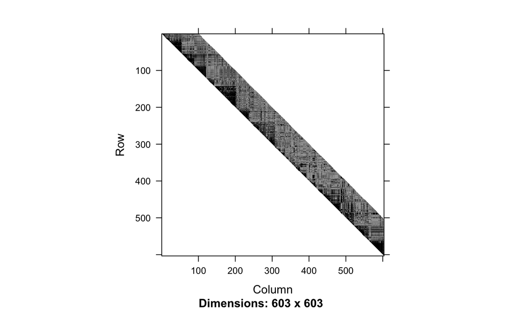

```r
# european population
image(ld.ceph$D.prime, lwd=0)
```

## LD in R(part 7)

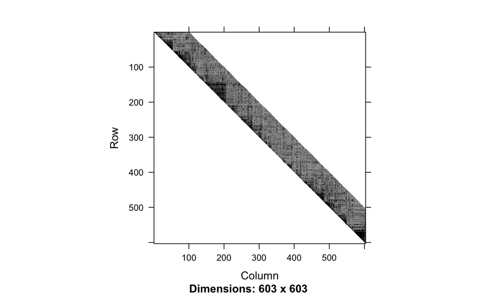

```r
image(ld.yri$D.prime, lwd=0)
```

## LD in R(part 8)

Takeaways:  
* There are fairly well-defined “blocks” of LD, and * LD is more pronounced in the Europeans than in the Africans. The second point is demonstrated by extracting the D-prime values from the matrices. We can see it by looking at the quantiles.

```r
quantile(ld.ceph$D.prime@x, na.rm=TRUE)
```

```
##        0%       25%       50%       75%      100%
## 0.0000000 0.1284448 0.2966491 0.6373796 1.0000000
```

```r
quantile(ld.yri$D.prime@x, na.rm=TRUE)
```

```
##        0%       25%       50%       75%      100%
## 0.0000000 0.1066341 0.2438494 0.5098348 1.0000000
```

## LD in R (part 9)

- The current plot is pretty hard to see, would be easier to see if we can see it in color.
- We first create a set of 10 colours ranging from yellow (for low values) to red (for high values)

```r
spectrum <- rainbow(10, start=0, end=1/6)[10:1]
print(spectrum)
```

```
##  [1] "#FFFF00FF" "#FFE300FF" "#FFC600FF" "#FFAA00FF" "#FF8E00FF"
##  [6] "#FF7100FF" "#FF5500FF" "#FF3900FF" "#FF1C00FF" "#FF0000FF"
```

## LD in R (part 10)

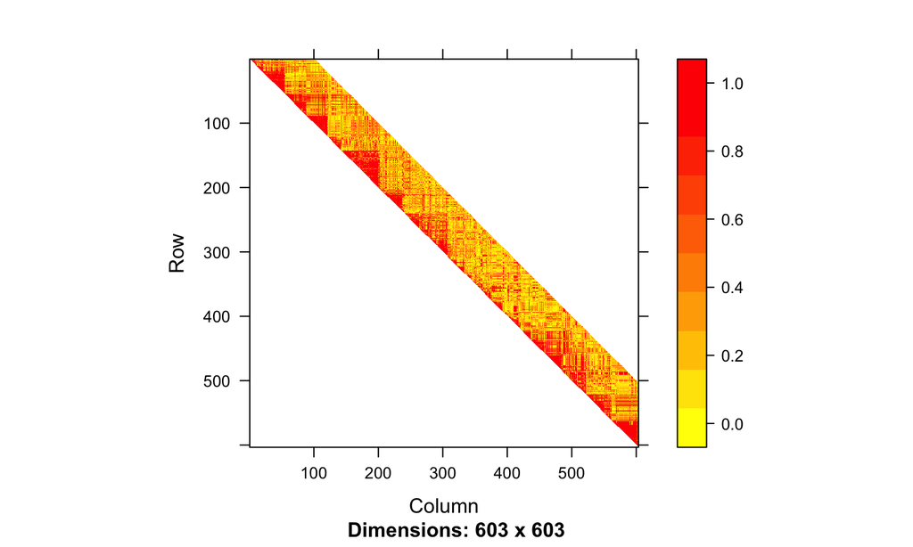

```r
image(ld.ceph$D.prime, lwd=0, cuts=9, col.regions=spectrum, colorkey=TRUE)
```

## LD in R (part 11)

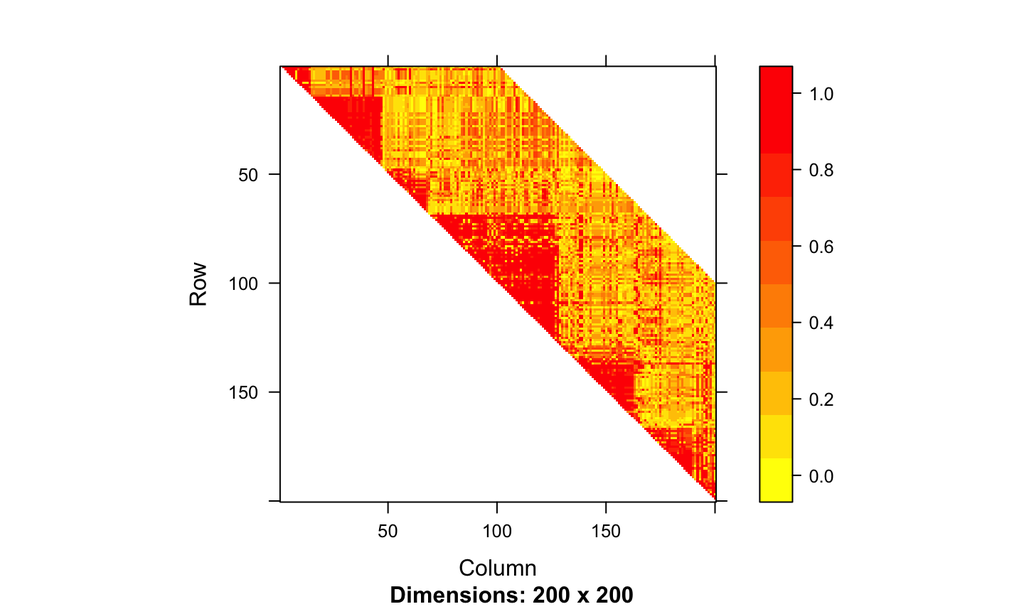

```r
image(ld.ceph$D.prime[75:274,75:274], lwd=0, cuts=9,
      col.regions=spectrum,colorkey=TRUE)
```

## Why do we care about LD

We care because a lot of the methods out there require LD or use it in some way.

## More on Hypothesis Testing

## Motivation

- Say you have a set of hypotheses that you wish to test simultaneously. The first idea that might come to mind is to test each hypothesis separately, using some level of significance \(\alpha\).
- At first blush, this doesn’t seem like a bad idea. However, consider a case where you have 20 hypotheses to test, and a significance level of 0.05. What’s the probability of observing at least one significant result just due to chance?

## Calculation

\[ P(at\,least\,one\,result\,is\,significant) = \\ 1 - P(no\,results\,are\,significant) \\ = 1 - (1 - 0.05)^{20} = 0.641 \]

So, with 20 tests being considered, we have a 64% chance of observing at least one significantresult, even if all of the tests are actually not significant.

## Bonferroni Correction

As we saw last week, Bonferroni correction can be used to change the critical p value that we want to hit.

## Bonferroni Correction Code

```r
pvals = c(.001, .001, .001, .02, .22, .59, .87)
BONF = p.adjust(pvals, "bonferroni")
BH = p.adjust(pvals, "BH")
res = cbind(pvals, BH=round(BH, 3), BONF=round(BONF, 3))
```

## Bonferroni Correction Code (Part 2)

```r
# set a method so this will fit
plot.p.values <- function(){
  matplot(res, ylab="p-values", xlab="sorted outcomes")
  abline(h=0.05, lty=2)
  matlines(res)
  legend(1, .9, legend=c("Bonferroni", "Benjamini-Hochberg", "Unadjusted"),
       col=c(3, 2, 1), lty=c(3, 2, 1), cex=0.7)
}
```

## Bonferroni Correction Code (Part 3)

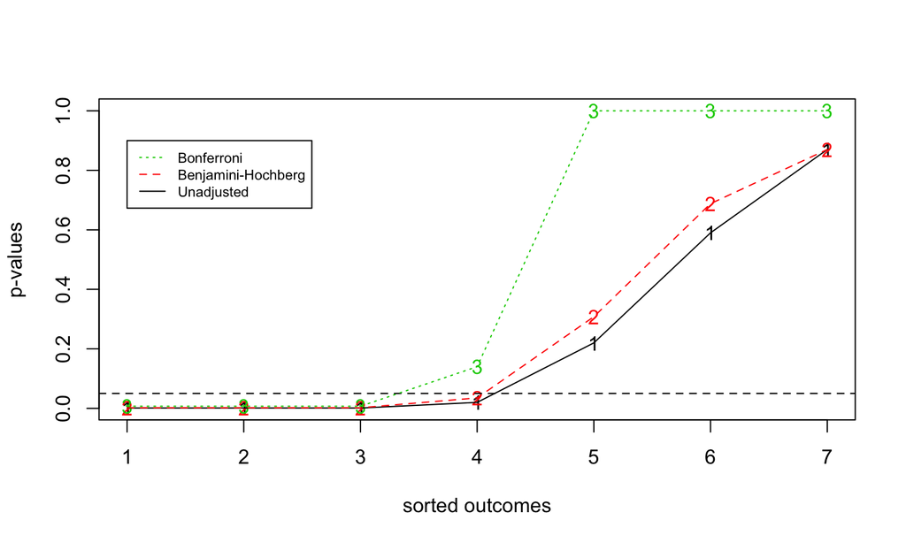

```r
plot.p.values()
```

## Another Example

```r
require(graphics)
set.seed(123)
x <- rnorm(50, mean = c(rep(0, 25), rep(3, 25)))
p <- 2*pnorm(sort(-abs(x)))
round(p, 3)
```

```
##  [1] 0.000 0.000 0.000 0.000 0.000 0.000 0.000 0.000 0.000 0.000 0.001
## [12] 0.002 0.003 0.004 0.005 0.007 0.007 0.009 0.009 0.011 0.021 0.049
## [23] 0.061 0.063 0.074 0.083 0.086 0.119 0.189 0.206 0.221 0.286 0.305
## [34] 0.466 0.483 0.492 0.532 0.575 0.578 0.619 0.636 0.645 0.656 0.689
## [45] 0.719 0.818 0.827 0.897 0.912 0.944
```

```r
round(p.adjust(p), 3)
```

```
##  [1] 0.000 0.001 0.001 0.005 0.005 0.006 0.006 0.007 0.009 0.016 0.024
## [12] 0.063 0.125 0.131 0.189 0.239 0.240 0.291 0.301 0.350 0.635 1.000
## [23] 1.000 1.000 1.000 1.000 1.000 1.000 1.000 1.000 1.000 1.000 1.000
## [34] 1.000 1.000 1.000 1.000 1.000 1.000 1.000 1.000 1.000 1.000 1.000
## [45] 1.000 1.000 1.000 1.000 1.000 1.000
```

```r
round(p.adjust(p, "BH"), 3)
```

```
##  [1] 0.000 0.000 0.000 0.001 0.001 0.001 0.001 0.001 0.001 0.002 0.003
## [12] 0.007 0.013 0.013 0.017 0.021 0.021 0.024 0.025 0.028 0.050 0.112
## [23] 0.130 0.130 0.148 0.159 0.160 0.213 0.326 0.343 0.356 0.446 0.462
## [34] 0.684 0.684 0.684 0.719 0.741 0.741 0.763 0.763 0.763 0.763 0.782
## [45] 0.799 0.880 0.880 0.930 0.930 0.944
```

## Another Example (part 2)

```r
## or all of them at once (dropping the "fdr" alias):
p.adjust.M <- p.adjust.methods[p.adjust.methods != "fdr"]
p.adj    <- sapply(p.adjust.M, function(meth) p.adjust(p, meth))
round(p.adj, 3)
```

```
##        holm hochberg hommel bonferroni    BH    BY  none
##  [1,] 0.000    0.000  0.000      0.000 0.000 0.000 0.000
##  [2,] 0.001    0.001  0.001      0.001 0.000 0.002 0.000
##  [3,] 0.001    0.001  0.001      0.001 0.000 0.002 0.000
##  [4,] 0.005    0.005  0.004      0.005 0.001 0.004 0.000
##  [5,] 0.005    0.005  0.005      0.005 0.001 0.004 0.000
##  [6,] 0.006    0.006  0.005      0.006 0.001 0.004 0.000
##  [7,] 0.006    0.006  0.006      0.007 0.001 0.004 0.000
##  [8,] 0.007    0.007  0.007      0.008 0.001 0.004 0.000
##  [9,] 0.009    0.009  0.009      0.011 0.001 0.006 0.000
## [10,] 0.016    0.016  0.015      0.019 0.002 0.009 0.000
## [11,] 0.024    0.024  0.024      0.031 0.003 0.013 0.001
## [12,] 0.063    0.063  0.058      0.081 0.007 0.030 0.002
## [13,] 0.125    0.125  0.109      0.165 0.013 0.057 0.003
## [14,] 0.131    0.131  0.117      0.177 0.013 0.057 0.004
```

[output cut: 36 more lines]

```r
## or a bit nicer:
noquote(apply(p.adj, 2, format.pval, digits = 3))
```

```
##       holm     hochberg hommel   bonferroni BH       BY      none
##  [1,] 1.18e-05 1.18e-05 1.18e-05 1.18e-05   1.18e-05 5.3e-05 2.35e-07
##  [2,] 0.00103  0.00103  0.00101  0.00105    0.000429 0.00193 2.10e-05
##  [3,] 0.00124  0.00124  0.00124  0.00129    0.000429 0.00193 2.58e-05
##  [4,] 0.00461  0.00461  0.00422  0.00491    0.000947 0.00426 9.81e-05
##  [5,] 0.00484  0.00484  0.00453  0.00526    0.000947 0.00426 0.000105
##  [6,] 0.00559  0.00559  0.00521  0.00621    0.000947 0.00426 0.000124
##  [7,] 0.00583  0.00583  0.00557  0.00663    0.000947 0.00426 0.000133
##  [8,] 0.00674  0.00674  0.00659  0.00784    0.000980 0.00441 0.000157
##  [9,] 0.00947  0.00947  0.00924  0.01127    0.001253 0.00564 0.000225
## [10,] 0.01556  0.01556  0.01518  0.01898    0.001898 0.00854 0.000380
## [11,] 0.02446  0.02446  0.02446  0.03057    0.002780 0.01251 0.000611
## [12,] 0.06294  0.06294  0.05810  0.08070    0.006725 0.03026 0.001614
## [13,] 0.12549  0.12549  0.10898  0.16512    0.012637 0.05686 0.003302
## [14,] 0.13092  0.13092  0.11677  0.17692    0.012637 0.05686 0.003538
```

[output cut: 36 more lines]

## Another Example (part 3)

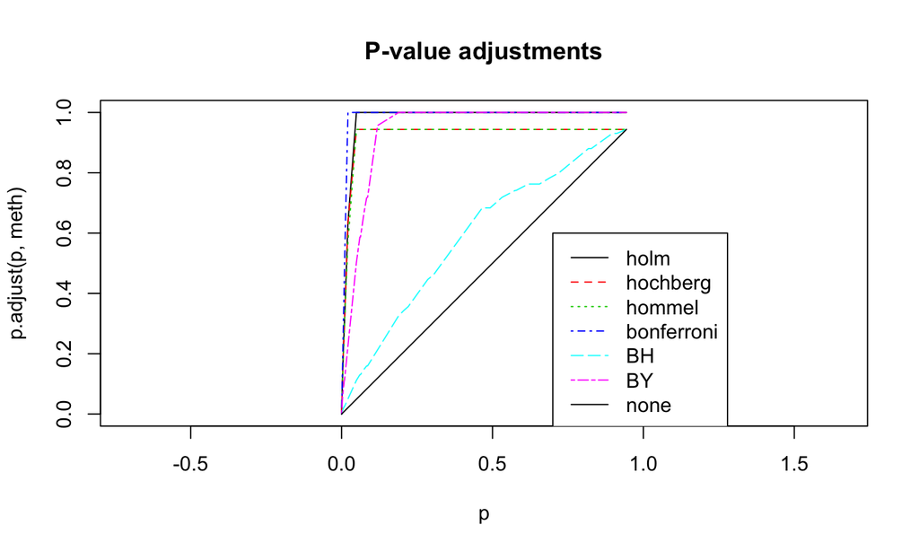

```r
matplot(p, p.adj, ylab="p.adjust(p, meth)", type = "l",
        asp = 1, lty = 1:6,main = "P-value adjustments")
legend(0.7, 0.6, p.adjust.M, col = 1:6, lty = 1:6)
```